# Analyzing Movie Ratings

Sofiane Ikkour

#### **Context:**

This project is about web scraping in which we’ll perform practical web data extraction in order to analyze movie ratings. The web page we’ll use is [IMDB](https://www.imdb.com/). IMDB is the world’s most popular source for movie, TV, and celebrity content.

#### **Objective:**

The goal is to extract data from the top 30 movies between [March and July 2020](http://dataquestio.github.io/web-scraping-pages/IMDb-DQgp.html). We can extract various details, including a movie’s title, description actors, director, genre, runtime, and ratings. Then, we’ll investigate the correlation between ratings and user votes.

**Note:** This code was written on RStudio.  
**Language:** R.  
**Packages:** rvest, dplyr, ggplot2, readr, stringr.

First of all, let’s take a look at the page we’ll work with which is illustrated below:

[figure not shown]

IMDB

**Load the relevant libraries and web page**

Let’s load the web page and the necessary packages.

```r
# load the relevant libraries
library(rvest)
library(dplyr)
```

```r
library(ggplot2)
library(readr)
library(stringr)

# assign the URL to a variable named url
url <- "http://dataquestio.github.io/web-scraping-pages/IMDb-DQgp.html"

# load the web page content
wp_content <- read_html(url)
```

**Analysis and discussion**

By looking at the web page, we can make two remarks:

1. The blocks from one movie to another are similar so they probably use the same selectors.  
   Here’s the first block: the one from *Mulan*. The elements we want to extract are highlighted in red:

[figure not shown]

Mulan

2. There are some missing values. The ratings and user votes are missing in some movies.

[figure not shown]

A quiet place

The Browser Developer Tools is used to access the page’s code. Here’s an HTML snippet code which identifies the block:

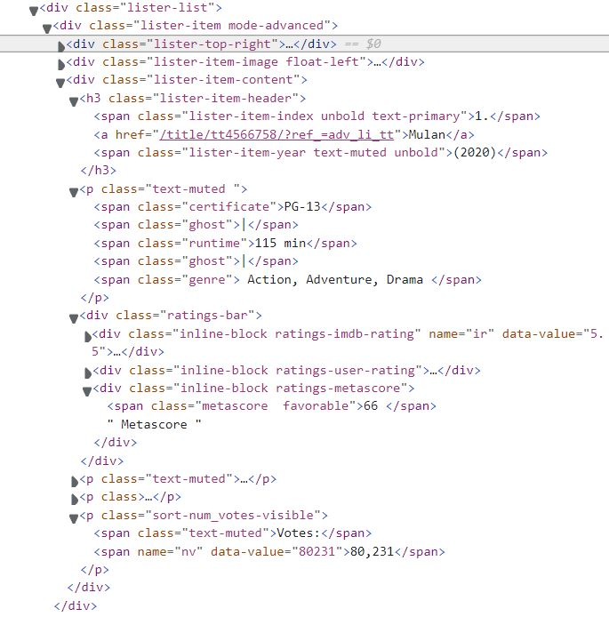

Snippet Code Mulan

**Extract data**

The next step consists in browsing the code to find the selectors of the elements. We’ll then check how many elements we can successfully capture with a selector and extract the expected data from the page.

First we need to extract the movie’s titles and the release years.

[figure not shown]

Title

```r
# find the CSS selector for the movies' titles and assign the result to a variable
selector_1 <- ".lister-item-header a"

# extract the movies' titles
titles <- wp_content %>%
  html_nodes(selector_1) %>%
  html_text()

# print the titles vector
print(titles)
```

```
##  [1] "Mulan"
##  [2] "The Call"
##  [3] "Greenland"
##  [4] "Don't Listen"
##  [5] "Unhinged"
##  [6] "Ava"
##  [7] "The Hunt"
##  [8] "Ghosts of War"
##  [9] "Hamilton"
## [10] "The Old Guard"
## [11] "The Secret: Dare to Dream"
## [12] "The Outpost"
## [13] "Extraction"
## [14] "Train to Busan Presents: Peninsula"
## [15] "Greyhound"
## [16] "The King of Staten Island"
## [17] "A Quiet Place Part II"
## [18] "Bloodshot"
## [19] "The Dark and the Wicked"
## [20] "Arkansas"
## [21] "The Rental"
## [22] "Trolls World Tour"
## [23] "Sputnik"
## [24] "Eurovision Song Contest: The Story of Fire Saga"
## [25] "Inheritance"
## [26] "Spenser Confidential"
## [27] "The Tax Collector"
## [28] "The Way Back"
## [29] "The Silencing"
## [30] "Archive"
```

```r
# find the CSS selector for the release years and assign the result to a variable
selector_2 <- ".text-muted.unbold"

# extract the movies' years
release_years <- wp_content %>%
  html_nodes(selector_2) %>%
  html_text()

# convert the values from character to numeric data type
release_years <- parse_number(release_years)

# print the release_years vector
release_years
```

```
##  [1] 2020 2020 2020 2020 2020 2020 2020 2020 2020 2020 2020 2020 2020 2020 2020
## [16] 2020 2020 2020 2020 2020 2020 2020 2020 2020 2020 2020 2020 2020 2020 2020
```

We want now to extract the movies’ runtimes and genres.

[figure not shown]

Runtimes_genre

```r
# find the runtime CSS selector and assign the result to a variable
selector_3 <- ".runtime"

# extract the movies' runtimes
runtimes <- wp_content %>%
  html_nodes(selector_3) %>%
  html_text()

# convert the values from character to numeric data type
runtimes <- parse_number(runtimes)

# print the runtimes vector
print(runtimes)
```

```
##  [1] 115 112 119  97  90  96  90  94 160 125 107 123 116 116  91 136  97 109  95
## [20] 117  88  90 113 123 111 111  95 108  93 109
```

```r
# find the movies' genres CSS selector and assign the result to a variable
selector_4 <- ".genre"

# extract the movies' genres
genres <- wp_content %>%
  html_nodes(selector_4) %>%
  html_text()

# print the genres vector
print(genres)
```

```
##  [1] "\nAction, Adventure, Drama            "
##  [2] "\nHorror, Mystery, Thriller            "
##  [3] "\nAction, Drama, Thriller            "
##  [4] "\nDrama, Horror, Thriller            "
##  [5] "\nAction, Thriller            "
##  [6] "\nAction, Crime, Drama            "
##  [7] "\nAction, Horror, Thriller            "
##  [8] "\nHorror, Thriller, War            "
##  [9] "\nBiography, Drama, History            "
## [10] "\nAction, Adventure, Fantasy            "
## [11] "\nDrama, Romance            "
## [12] "\nAction, Drama, History            "
## [13] "\nAction, Thriller            "
## [14] "\nAction, Horror, Thriller            "
## [15] "\nAction, Drama, History            "
## [16] "\nComedy, Drama            "
## [17] "\nDrama, Horror, Sci-Fi            "
## [18] "\nAction, Drama, Sci-Fi            "
## [19] "\nHorror            "
## [20] "\nCrime, Drama, Thriller            "
## [21] "\nHorror, Thriller            "
## [22] "\nAnimation, Adventure, Comedy            "
## [23] "\nDrama, Horror, Sci-Fi            "
## [24] "\nComedy, Music            "
## [25] "\nDrama, Mystery, Thriller            "
## [26] "\nAction, Comedy, Crime            "
## [27] "\nAction, Crime, Drama            "
## [28] "\nDrama, Sport            "
## [29] "\nAction, Crime, Thriller            "
## [30] "\nDrama, Sci-Fi, Thriller            "
```

```r
# the genre characters have whitespaces at the end, we need to remove them
genres <- str_trim(string = genres, side = "right")

# print the genres vector
print(genres)
```

```
##  [1] "\nAction, Adventure, Drama"     "\nHorror, Mystery, Thriller"
##  [3] "\nAction, Drama, Thriller"      "\nDrama, Horror, Thriller"
##  [5] "\nAction, Thriller"             "\nAction, Crime, Drama"
##  [7] "\nAction, Horror, Thriller"     "\nHorror, Thriller, War"
##  [9] "\nBiography, Drama, History"    "\nAction, Adventure, Fantasy"
## [11] "\nDrama, Romance"               "\nAction, Drama, History"
## [13] "\nAction, Thriller"             "\nAction, Horror, Thriller"
## [15] "\nAction, Drama, History"       "\nComedy, Drama"
## [17] "\nDrama, Horror, Sci-Fi"        "\nAction, Drama, Sci-Fi"
## [19] "\nHorror"                       "\nCrime, Drama, Thriller"
## [21] "\nHorror, Thriller"             "\nAnimation, Adventure, Comedy"
## [23] "\nDrama, Horror, Sci-Fi"        "\nComedy, Music"
## [25] "\nDrama, Mystery, Thriller"     "\nAction, Comedy, Crime"
## [27] "\nAction, Crime, Drama"         "\nDrama, Sport"
## [29] "\nAction, Crime, Thriller"      "\nDrama, Sci-Fi, Thriller"
```

Now we’ll extract the user ratings and metascores.

[figure not shown]

Ratings_Metascore

```r
# find the user ratings CSS selector and assign the result to a variable
selector_5 <- ".ratings-imdb-rating"

# extract the movies' user ratings
ratings <- wp_content %>%
  html_nodes(selector_5) %>%
  html_attr("data-value")

# convert the values from character to numeric data type
ratings <- as.numeric(ratings)

# print the ratings vector
print(ratings)
```

```
##  [1] 5.5 7.2 6.3 6.1 6.0 5.3 6.5 5.5 8.6 6.6 6.4 6.8 6.7 5.4 7.0 7.1 5.7 6.2 5.9
## [20] 5.7 6.1 6.4 6.5 5.5 6.2 4.7 6.7 6.1 6.3
```

```r
# find the metascore CSS selector and assign the result to a variable
selector_6 <- ".metascore"

# extract the movie metascore
metascore <- wp_content %>%
  html_nodes(selector_6) %>%
  html_text()

# print the metascore vector
print(metascore)
```

```
##  [1] "66        " "40        " "39        " "50        " "38        "
##  [6] "90        " "70        " "32        " "71        " "56        "
## [11] "51        " "64        " "67        " "44        " "72        "
## [16] "55        " "63        " "51        " "61        " "50        "
## [21] "31        " "49        " "22        " "66        " "67        "
```

```r
# remove the whitespaces at the end of each character
metascore <- str_trim(string = metascore, side = "right")

# convert from character to numeric data type
metascore <- as.numeric(metascore)

# print the metascore vector
print(metascore)
```

```
##  [1] 66 40 39 50 38 90 70 32 71 56 51 64 67 44 72 55 63 51 61 50 31 49 22 66 67
```

Finally, we extract the votes.

[figure not shown]

```r
# find the votes CSS selector and assign the result to a variable
selector_7 <- ".text-muted+ span"

# extract the votes
votes <- wp_content %>%
  html_nodes(selector_7) %>%
  html_text()

# convert the values from character to numeric data type
votes <- parse_number(votes)

# print the votes vector
print(votes)
```

```
##  [1]  80231   6559  27482   4879  25316  20882  62277   4886  48663 117211
## [11]   5420  17001 151319  16815  60885  29278  57763   3701   7951  13965
## [21]  14792  10516  69186   7837  65768   7416  28300   9355   9271
```

**Combine the extracted data**

```r
# create a function named append_vector() capable of inserting NA values
append_vector <- function(vector, indices, values) {

  ## Creating the current indices of the vector
  vector_current_indices <- 1:length(vector)

  ## Adding small amount of values (between 0 and 0.9) to the `indices`
  new_indices <- indices + seq(0, 0.9, length.out = length(indices))

  ## Appending the `new_indices` to the current vector indices
  f_indices <- c(vector_current_indices, new_indices)

  ## Ordering the indices
  ordered_indices <- order(f_indices)

  ## Appending the new value to the existing vector
  new_vector <- c(vector, values)

  ## Ordering the new vector wrt the ordered indices
  new_vector[ordered_indices]
}

# use the function to insert NA values into the metascore vector
# the NA values must be inserted after the positions 1, 1, 1, &3, and 24
metascore <- append_vector(metascore, c(1, 1, 1, 3, 24), NA)

# remove the 17th element from the vector titles
titles <- titles[-17]

# remove the 17th element from the vector release_years
release_years <- release_years[-17]

# remove the 17th element from the vector runtimes
runtimes <- runtimes[-17]

# remove the 17th element from the vector genres
genres <- genres[-17]

# remove the 17th element from the vector metascore
metascore <- metascore[-17]
```

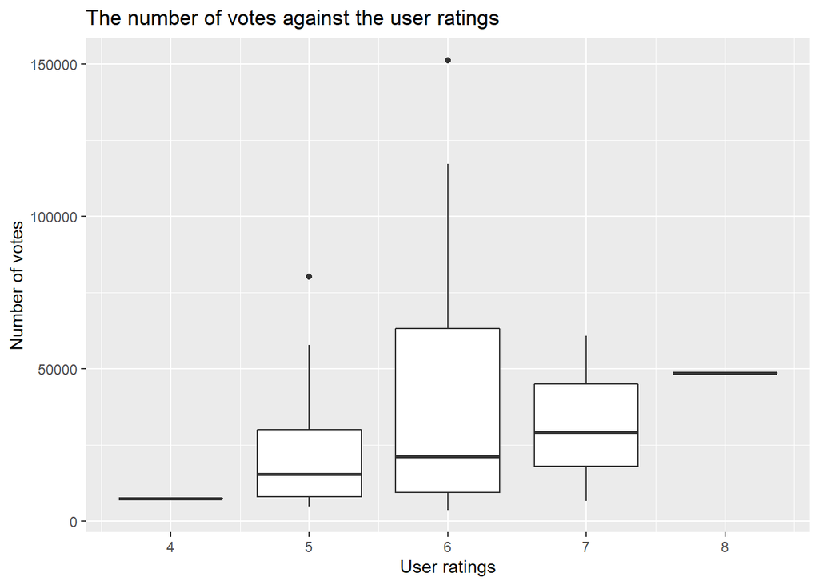

```r
# create a dataframe with the extracted data
df <- tibble(titles, release_years, runtimes, genres, ratings, votes, metascore)

# keep only integers for each vector using the floor() function
# df$titles <- floor(df$titles)
df <- df %>%
  mutate(release_years = floor(release_years)) %>%
  mutate(runtimes = floor(runtimes)) %>%
  mutate(ratings = floor(ratings)) %>%
  mutate(votes = floor(votes)) %>%
  mutate(metascore = floor(metascore))

# create a boxplot that shows the number of votes against the user ratings
ggplot(df, aes(x = ratings, y = votes, group = ratings)) +
  geom_boxplot() +
  labs(
    title = "The number of votes against the user ratings",
    x = "User ratings",
    y = "Number of votes"
  )
```